# Project: Soccer Data Analysis

- Introduction
- Data Wrangling
- Exploratory Data Analysis
- Conclusions

## Introduction

**The dataset** we are going to use for analysis comes form four csv files contained in the database_soccer folder, Country ,Leagues ,Matchs and Teams all combined in one dataframe matches_df through many steps bellow, and in which we find :

- 11 european countries along with their 11 championship
- the names of all teams competitors for all 11 countries
- the stage represents the order of the week (generally 34) in the year in which each team play one match
- the date of each match of all seasons and the season (the year) from 2008 to 2016
- the result of each match with the number of goals of both home and away team

**The purpose** is trying to answer the following questions :

1. Which league/country has the most goals in the first 3 stages of the season, and for the first three season from 2008 to 2010 ?
2. How does the average goal scored in each league evolve in the seasons 2008/2009 , 2010/2011 and 2014/2015?

```python
%matplotlib inline

import pandas as pd
import numpy as np
import matplotlib.pyplot as plt
```

## Data Wrangling

### General Properties

> **For the first part** we load in csv files we need, then we choose the approriate variables serving our investigation

```python
# First of all we call the four csv files we are going to use
matches_df = pd.read_csv('Match.csv')
teams_df = pd.read_csv('Team.csv')
leagues_df = pd.read_csv('League.csv')
countries_df = pd.read_csv('Country.csv')
# This instuction allows us to see all column labels
pd.set_option('display.max_columns', None)
```

```python
# Exploring matches dataframe
matches_df.info()
```

```
<class 'pandas.core.frame.DataFrame'>
RangeIndex: 25979 entries, 0 to 25978
Columns: 115 entries, id to BSA
dtypes: float64(96), int64(9), object(10)
memory usage: 22.8+ MB
```

```python
matches_df.head()
```

|  | id | country_id | league_id | season | stage | date | match_api_id | home_team_api_id | away_team_api_id | home_team_goal | away_team_goal | home_player_X1 | home_player_X2 | home_player_X3 | home_player_X4 | home_player_X5 | home_player_X6 | home_player_X7 | home_player_X8 | home_player_X9 | home_player_X10 | home_player_X11 | away_player_X1 | away_player_X2 | away_player_X3 | away_player_X4 | away_player_X5 | away_player_X6 | away_player_X7 | … |
| --- | --- | --- | --- | --- | --- | --- | --- | --- | --- | --- | --- | --- | --- | --- | --- | --- | --- | --- | --- | --- | --- | --- | --- | --- | --- | --- | --- | --- | --- | --- |
| 0 | 1 | 1 | 1 | 2008/2009 | 1 | 2008-08-17 00:00:00 | 492473 | 9987 | 9993 | 1 | 1 | NaN | NaN | NaN | NaN | NaN | NaN | NaN | NaN | NaN | NaN | NaN | NaN | NaN | NaN | NaN | NaN | NaN | NaN | … |
| 1 | 2 | 1 | 1 | 2008/2009 | 1 | 2008-08-16 00:00:00 | 492474 | 10000 | 9994 | 0 | 0 | NaN | NaN | NaN | NaN | NaN | NaN | NaN | NaN | NaN | NaN | NaN | NaN | NaN | NaN | NaN | NaN | NaN | NaN | … |
| 2 | 3 | 1 | 1 | 2008/2009 | 1 | 2008-08-16 00:00:00 | 492475 | 9984 | 8635 | 0 | 3 | NaN | NaN | NaN | NaN | NaN | NaN | NaN | NaN | NaN | NaN | NaN | NaN | NaN | NaN | NaN | NaN | NaN | NaN | … |
| 3 | 4 | 1 | 1 | 2008/2009 | 1 | 2008-08-17 00:00:00 | 492476 | 9991 | 9998 | 5 | 0 | NaN | NaN | NaN | NaN | NaN | NaN | NaN | NaN | NaN | NaN | NaN | NaN | NaN | NaN | NaN | NaN | NaN | NaN | … |
| 4 | 5 | 1 | 1 | 2008/2009 | 1 | 2008-08-16 00:00:00 | 492477 | 7947 | 9985 | 1 | 3 | NaN | NaN | NaN | NaN | NaN | NaN | NaN | NaN | NaN | NaN | NaN | NaN | NaN | NaN | NaN | NaN | NaN | NaN | … |

> now we can see the whole columns in matche_df and we choose only the colums that will serve our needs, also we do the same thing with teams_df and extracting teams names along with their unique id

```python
# Choosing only desired columns for the rest of the analysis
matches_df = matches_df.iloc[: , np.r_[: ,1:6, 7:11]]
matches_df.head()
```

|  | country_id | league_id | season | stage | date | home_team_api_id | away_team_api_id | home_team_goal | away_team_goal |
| --- | --- | --- | --- | --- | --- | --- | --- | --- | --- |
| 0 | 1 | 1 | 2008/2009 | 1 | 2008-08-17 00:00:00 | 9987 | 9993 | 1 | 1 |
| 1 | 1 | 1 | 2008/2009 | 1 | 2008-08-16 00:00:00 | 10000 | 9994 | 0 | 0 |
| 2 | 1 | 1 | 2008/2009 | 1 | 2008-08-16 00:00:00 | 9984 | 8635 | 0 | 3 |
| 3 | 1 | 1 | 2008/2009 | 1 | 2008-08-17 00:00:00 | 9991 | 9998 | 5 | 0 |
| 4 | 1 | 1 | 2008/2009 | 1 | 2008-08-16 00:00:00 | 7947 | 9985 | 1 | 3 |

```python
# Exploring teams dataframe
teams_df.head()
```

|  | id | team_api_id | team_fifa_api_id | team_long_name | team_short_name |
| --- | --- | --- | --- | --- | --- |
| 0 | 1 | 9987 | 673.0 | KRC Genk | GEN |
| 1 | 2 | 9993 | 675.0 | Beerschot AC | BAC |
| 2 | 3 | 10000 | 15005.0 | SV Zulte-Waregem | ZUL |
| 3 | 4 | 9994 | 2007.0 | Sporting Lokeren | LOK |
| 4 | 5 | 9984 | 1750.0 | KSV Cercle Brugge | CEB |

```python
# Choosing only desired columns for the rest of the analysis
teams_df = teams_df[['team_api_id','team_long_name']]
```

```python
# Now we check the number of empty rows in matches_df
matches_df.isnull().any(axis=1).sum()
```

```
0
```

> Hence we don't need to remove any row,after we get to explore both the country and the league dataframes

```python
leagues_df
```

|  | id | country_id | name |
| --- | --- | --- | --- |
| 0 | 1 | 1 | Belgium Jupiler League |
| 1 | 1729 | 1729 | England Premier League |
| 2 | 4769 | 4769 | France Ligue 1 |
| 3 | 7809 | 7809 | Germany 1. Bundesliga |
| 4 | 10257 | 10257 | Italy Serie A |
| 5 | 13274 | 13274 | Netherlands Eredivisie |
| 6 | 15722 | 15722 | Poland Ekstraklasa |
| 7 | 17642 | 17642 | Portugal Liga ZON Sagres |
| 8 | 19694 | 19694 | Scotland Premier League |
| 9 | 21518 | 21518 | Spain LIGA BBVA |
| 10 | 24558 | 24558 | Switzerland Super League |

```python
countries_df
```

|  | id | name |
| --- | --- | --- |
| 0 | 1 | Belgium |
| 1 | 1729 | England |
| 2 | 4769 | France |
| 3 | 7809 | Germany |
| 4 | 10257 | Italy |
| 5 | 13274 | Netherlands |
| 6 | 15722 | Poland |
| 7 | 17642 | Portugal |
| 8 | 19694 | Scotland |
| 9 | 21518 | Spain |
| 10 | 24558 | Switzerland |

> As we found the same column label "name" in both dataframes, we change them to be able to join them with matches_df later:

```python
leagues_df = leagues_df.rename(columns={'name':'league_name'})
countries_df = countries_df.rename(columns={'name':'country_name'})
```

### Data Cleaning

> **for the second part** we do all necessary cleaning to the matches_df, such as droping unnecessary columns and joining all necesary data in one dataframe matches_df ,also we delete date time we don't need from the date column:

```python
# Here we are joining countries and leagues names instead of id numbers
matches_df = matches_df.set_index('country_id').join(countries_df.set_index('id'))
matches_df = matches_df.set_index('league_id').join(leagues_df.set_index('id'))
matches_df.head()
```

|  | season | stage | date | home_team_api_id | away_team_api_id | home_team_goal | away_team_goal | country_name | country_id | league_name |
| --- | --- | --- | --- | --- | --- | --- | --- | --- | --- | --- |
| 1 | 2008/2009 | 1 | 2008-08-17 00:00:00 | 9987 | 9993 | 1 | 1 | Belgium | 1 | Belgium Jupiler League |
| 1 | 2008/2009 | 1 | 2008-08-16 00:00:00 | 10000 | 9994 | 0 | 0 | Belgium | 1 | Belgium Jupiler League |
| 1 | 2008/2009 | 1 | 2008-08-16 00:00:00 | 9984 | 8635 | 0 | 3 | Belgium | 1 | Belgium Jupiler League |
| 1 | 2008/2009 | 1 | 2008-08-17 00:00:00 | 9991 | 9998 | 5 | 0 | Belgium | 1 | Belgium Jupiler League |
| 1 | 2008/2009 | 1 | 2008-08-16 00:00:00 | 7947 | 9985 | 1 | 3 | Belgium | 1 | Belgium Jupiler League |

```python
# We drop the country_id column as we don"t need it anymore
matches_df.drop('country_id', axis=1, inplace=True)
```

```python
# We join home teams names istead of home_team_api_id the same way as for countries and leagues
matches_df = matches_df.set_index('home_team_api_id').join(teams_df.set_index('team_api_id'))
# We change the column name to be able to do joinig operation to away teams
matches_df.rename(columns={'team_long_name':'home_team_name'}, inplace=True)
```

```python
matches_df.head()
```

|  | season | stage | date | away_team_api_id | home_team_goal | away_team_goal | country_name | league_name | home_team_name |
| --- | --- | --- | --- | --- | --- | --- | --- | --- | --- |
| 1601 | 2008/2009 | 12 | 2008-11-08 00:00:00 | 8322 | 0 | 0 | Poland | Poland Ekstraklasa | Ruch Chorzów |
| 1601 | 2008/2009 | 13 | 2008-11-11 00:00:00 | 8025 | 1 | 2 | Poland | Poland Ekstraklasa | Ruch Chorzów |
| 1601 | 2008/2009 | 15 | 2008-11-21 00:00:00 | 8673 | 0 | 1 | Poland | Poland Ekstraklasa | Ruch Chorzów |
| 1601 | 2008/2009 | 16 | 2008-11-29 00:00:00 | 10265 | 1 | 0 | Poland | Poland Ekstraklasa | Ruch Chorzów |
| 1601 | 2008/2009 | 18 | 2009-02-28 00:00:00 | 8020 | 0 | 1 | Poland | Poland Ekstraklasa | Ruch Chorzów |

```python
# Here we join away teams names istead of away_team_api_id
matches_df = matches_df.set_index('away_team_api_id').join(teams_df.set_index('team_api_id'))
matches_df.rename(columns={'team_long_name':'away_team_name'}, inplace=True)
```

```python
# Making the index of matches_df start from 0
matches_df.reset_index(drop=True, inplace=True)
matches_df.head()
```

|  | season | stage | date | home_team_goal | away_team_goal | country_name | league_name | home_team_name | away_team_name |
| --- | --- | --- | --- | --- | --- | --- | --- | --- | --- |
| 0 | 2008/2009 | 24 | 2009-04-19 00:00:00 | 1 | 0 | Poland | Poland Ekstraklasa | Jagiellonia Białystok | Ruch Chorzów |
| 1 | 2009/2010 | 28 | 2010-05-07 00:00:00 | 1 | 0 | Poland | Poland Ekstraklasa | Jagiellonia Białystok | Ruch Chorzów |
| 2 | 2010/2011 | 30 | 2011-05-29 00:00:00 | 2 | 1 | Poland | Poland Ekstraklasa | Jagiellonia Białystok | Ruch Chorzów |
| 3 | 2011/2012 | 20 | 2012-03-04 00:00:00 | 0 | 1 | Poland | Poland Ekstraklasa | Jagiellonia Białystok | Ruch Chorzów |
| 4 | 2012/2013 | 30 | 2013-06-02 00:00:00 | 1 | 0 | Poland | Poland Ekstraklasa | Jagiellonia Białystok | Ruch Chorzów |

```python
# This instuction remove the date time from 'date' column to make the dataset more clear
matches_df['date'] = pd.to_datetime(matches_df['date']).dt.date
```

> Now this the dataframe matches_df we are going to use after all wrangling process.

```python
matches_df.head()
```

|  | season | stage | date | home_team_goal | away_team_goal | country_name | league_name | home_team_name | away_team_name |
| --- | --- | --- | --- | --- | --- | --- | --- | --- | --- |
| 0 | 2008/2009 | 24 | 2009-04-19 | 1 | 0 | Poland | Poland Ekstraklasa | Jagiellonia Białystok | Ruch Chorzów |
| 1 | 2009/2010 | 28 | 2010-05-07 | 1 | 0 | Poland | Poland Ekstraklasa | Jagiellonia Białystok | Ruch Chorzów |
| 2 | 2010/2011 | 30 | 2011-05-29 | 2 | 1 | Poland | Poland Ekstraklasa | Jagiellonia Białystok | Ruch Chorzów |
| 3 | 2011/2012 | 20 | 2012-03-04 | 0 | 1 | Poland | Poland Ekstraklasa | Jagiellonia Białystok | Ruch Chorzów |
| 4 | 2012/2013 | 30 | 2013-06-02 | 1 | 0 | Poland | Poland Ekstraklasa | Jagiellonia Białystok | Ruch Chorzów |

## Exploratory Data Analysis

### The Total Goals in The First Three Seasons/Stages

> Our purpose is to answer the first question which is trying to find the league/country that has the most goals in the first 3 stages of the season and for the first three season from 2008 to 2010 , as first step we add a column to our datafrrame containing the total number of goals scored each match , then we filter our dataframe:

```python
# First of all we add a new column to our dataset contains the total number of goals
matches_df['total_goals'] = matches_df['home_team_goal']+matches_df['away_team_goal']
```

```python
matches_df.head()
```

|  | season | stage | date | home_team_goal | away_team_goal | country_name | league_name | home_team_name | away_team_name | total_goals |
| --- | --- | --- | --- | --- | --- | --- | --- | --- | --- | --- |
| 0 | 2008/2009 | 24 | 2009-04-19 | 1 | 0 | Poland | Poland Ekstraklasa | Jagiellonia Białystok | Ruch Chorzów | 1 |
| 1 | 2009/2010 | 28 | 2010-05-07 | 1 | 0 | Poland | Poland Ekstraklasa | Jagiellonia Białystok | Ruch Chorzów | 1 |
| 2 | 2010/2011 | 30 | 2011-05-29 | 2 | 1 | Poland | Poland Ekstraklasa | Jagiellonia Białystok | Ruch Chorzów | 3 |
| 3 | 2011/2012 | 20 | 2012-03-04 | 0 | 1 | Poland | Poland Ekstraklasa | Jagiellonia Białystok | Ruch Chorzów | 1 |
| 4 | 2012/2013 | 30 | 2013-06-02 | 1 | 0 | Poland | Poland Ekstraklasa | Jagiellonia Białystok | Ruch Chorzów | 1 |

```python
# We filter the dataset to only first three seasons we need
three_seasons_df = matches_df.query('season=="2008/2009" | season=="2009/2010" | season=="2010/2011"')
three_seasons_df['season'].unique()
```

```
array(['2008/2009', '2009/2010', '2010/2011'], dtype=object)
```

```python
# Then we filter the dataset to only first three stages we need
three_stages_df = three_seasons_df.query('stage==1 | stage==2 | stage==3')
three_stages_df['stage'].unique()
```

```
array([1, 3, 2], dtype=int64)
```

```python
# now we set country and league name as indexes and see the total of goals
league_total_goals_df = three_stages_df.groupby(['country_name','league_name']).sum()
league_total_goals_df.iloc[:,1:]
```

| country_name | league_name | home_team_goal | away_team_goal | total_goals |
| --- | --- | --- | --- | --- |
| Belgium | Belgium Jupiler League | 118 | 83 | 201 |
| England | England Premier League | 138 | 110 | 248 |
| France | France Ligue 1 | 128 | 89 | 217 |
| Germany | Germany 1. Bundesliga | 125 | 119 | 244 |
| Italy | Italy Serie A | 128 | 94 | 222 |
| Netherlands | Netherlands Eredivisie | 140 | 107 | 247 |
| Poland | Poland Ekstraklasa | 108 | 75 | 183 |
| Portugal | Portugal Liga ZON Sagres | 79 | 59 | 138 |
| Scotland | Scotland Premier League | 74 | 65 | 139 |
| Spain | Spain LIGA BBVA | 136 | 106 | 242 |
| Switzerland | Switzerland Super League | 78 | 54 | 132 |

> We could see from the above table that the England Premier League has the highest total numbers of goals scored in the first three stages and seasons with 248 goals ,and we could check if this statement is true by executing the following instruction:

```python
#  This instruction below gives us the country/league name we search for
league_total_goals_df.index[league_total_goals_df['total_goals'] == max(league_total_goals_df['total_goals'])].tolist()
```

```
[('England', 'England Premier League')]
```

### Evolution of The Average of Goals Scored in Each League

> In order to answer the second question which consist of the evolution of the average goals scored in seasons : 2008/2009 , 2010/2011 and 2014/2015, for the first step we groupby season and league name and calculating the mean for each season and each league:

```python
# We are going to groupby season and league name
SandL_groupby_df = matches_df.groupby(['season','league_name']).mean()
SandL_groupby_df.head()
```

| season | league_name | stage | home_team_goal | away_team_goal | total_goals |
| --- | --- | --- | --- | --- | --- |
| 2008/2009 | Belgium Jupiler League | 17.5 | 1.630719 | 1.163399 | 2.794118 |
|  | England Premier League | 19.5 | 1.400000 | 1.078947 | 2.478947 |
|  | France Ligue 1 | 19.5 | 1.286842 | 0.971053 | 2.257895 |
|  | Germany 1. Bundesliga | 17.5 | 1.699346 | 1.222222 | 2.921569 |
|  | Italy Serie A | 19.5 | 1.521053 | 1.078947 | 2.600000 |

```python
# Now we are setting up a function that will plot the league names as horizontal bars, with the season given as an argument
def func_plot_bar(S):
    SandL_groupby_df.loc[S]['total_goals'].plot(kind='barh',figsize=(10,5))
    plt.title('Average number of goals scored in season for all leagues')
    plt.xlabel(f'{S} Season')
    plt.ylabel('Average number of goals');
```

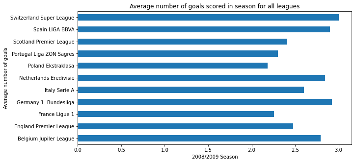

```python
# Plotting the bars for 2008/2009 Season
func_plot_bar('2008/2009')
```

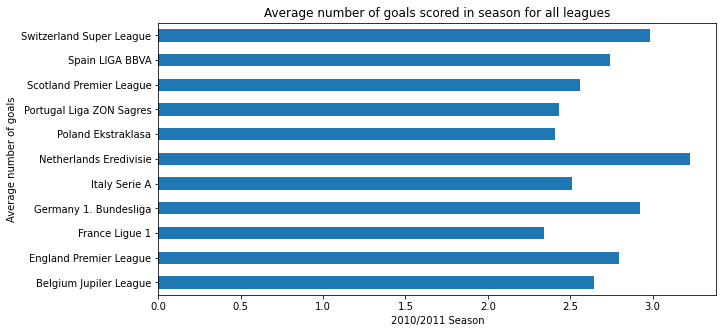

```python
# Plotting the bars for 2010/2011 Season
func_plot_bar('2010/2011')
```

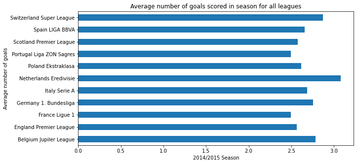

```python
# Plotting the bars for 2014/2015 Season
func_plot_bar('2014/2015')
```

> From the graphs above we can see that the gap between leagues in the average score is getting smaller in those three seasons, to see this more clearly, we are going to plot lines:

```python
# We use this function to plot a line graph for each desired season as an argument
def func_plot_line(S):
    plt.rcParams.update({'font.size': 25})
    plt.rcParams["figure.figsize"] = [30,15]
    plt.title(f'Average number of goals in each league for the {S} season')
    plt.plot(SandL_groupby_df.loc[S].index,SandL_groupby_df.loc[S]['total_goals'])
    plt.xticks(SandL_groupby_df.loc[S].index)
    plt.xticks(rotation='vertical')
    plt.xlabel(f'{S} Season')
    plt.ylabel('Average number of goals');
```

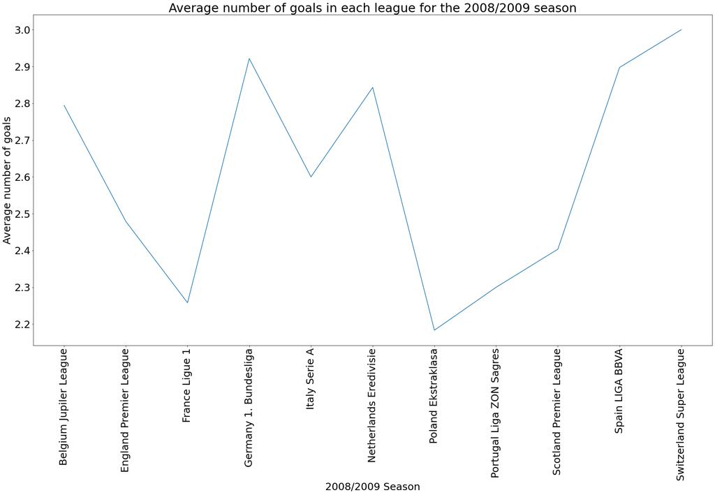

```python
func_plot_line('2008/2009')
```

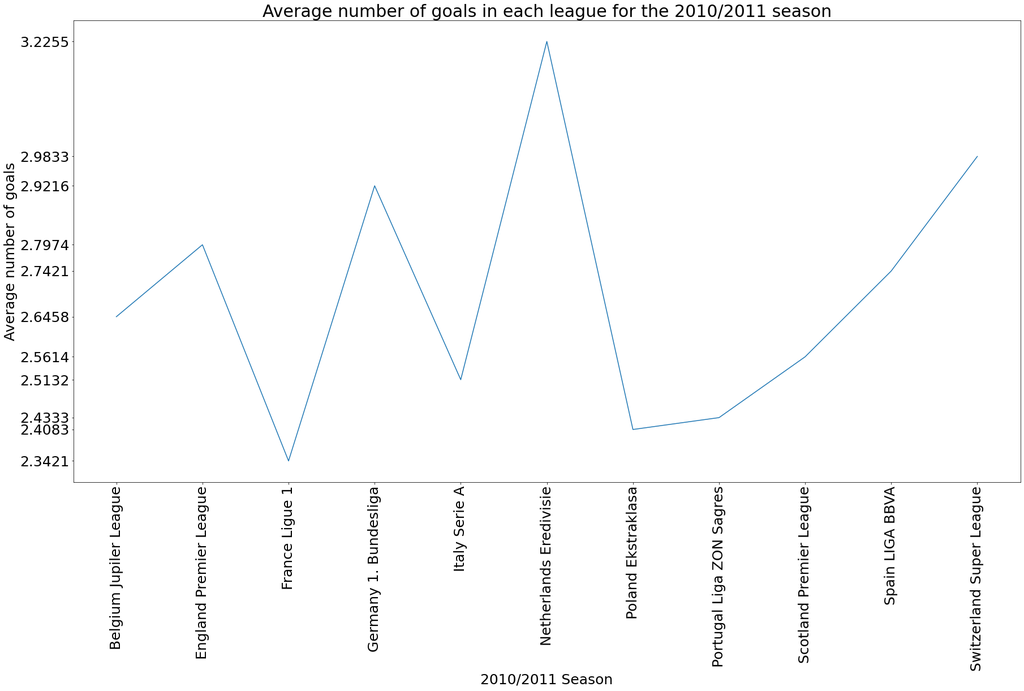

```python
func_plot_line('2010/2011')
```

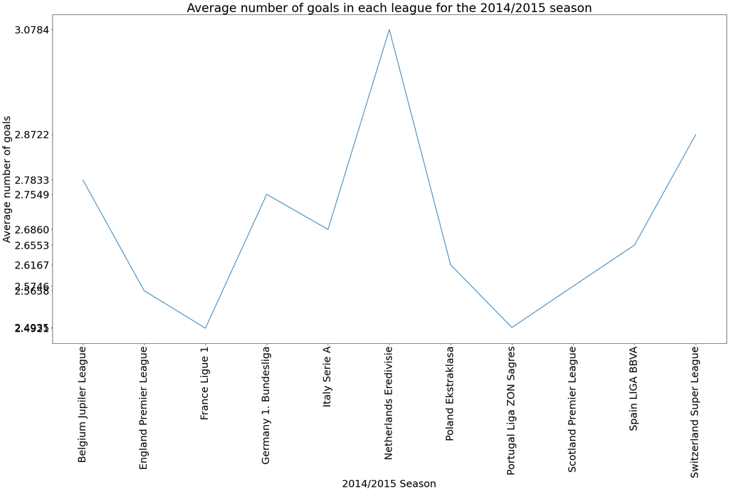

```python
func_plot_line('2014/2015')
```

> Hence we notice that the line graph becomes more and more stable, from the first to the third season in question, in other words the dispertion around the average of averages is decreasing from the first to the last season shown , and we could check this by calculating the standard deviation for each season and see if it gets smaller:

```python
def std_calculator(S):
    df.loc[S]['total_goals'].std()
```

[output not shown]

```python
[std_calculator('2008/2009'),std_calculator('2010/2011'),std_calculator('2014/2015')]
```

[output not shown]

## Conclusions

**To resume** our findings in this analysis for both questions we conclude that:

**The Limitations** are generally two:

- The first is the multi sources of the dataset as it comes from four csv files but originally it was one database in the form of SQLite file, hence I have been in several problems when I tried to join multiple tables into one, SQLite DB manager doesn't support full join as far as i can tell, hence I have to do it with pandas methods which will not seve us in the case of a large database.
- The second is in the graphs when I use plt.plot method in the line graphs since I could also use pd.plot method, but i came across problem of not showing x labels (names of leagues), thus I use plt.plot as a replacement.